# Introduction to `ggplot2` homework

Jack Ogilvie-Richards

#### Libraries

```r
library(tidyverse)
library(CodeClanData)
```

# MVP

This homework examines a dataset of students and their backpacks.

#### Question 1

```r
dim(backpack)
```

```
[1] 100   9
```

```r
head(backpack)
```

|  | backpack_weight | body_weight | ratio | back_problems | major | year | sex | status | units |
| --- | --- | --- | --- | --- | --- | --- | --- | --- | --- |
| 1 | 9 | 125 | 0.0720000 | 1 | Bio | 3 | Female | U | 13 |
| 2 | 8 | 195 | 0.0410256 | 0 | Philosophy | 5 | Male | U | 12 |
| 3 | 10 | 120 | 0.0833333 | 1 | GRC | 4 | Female | U | 14 |
| 4 | 6 | 155 | 0.0387097 | 0 | CSC | 6 | Male | G | 0 |
| 5 | 8 | 180 | 0.0444444 | 0 | EE | 2 | Female | U | 14 |
| 6 | 5 | 240 | 0.0208333 | 0 | History | 0 | Male | G | 0 |

```r
NA
NA
```

#### Question 2

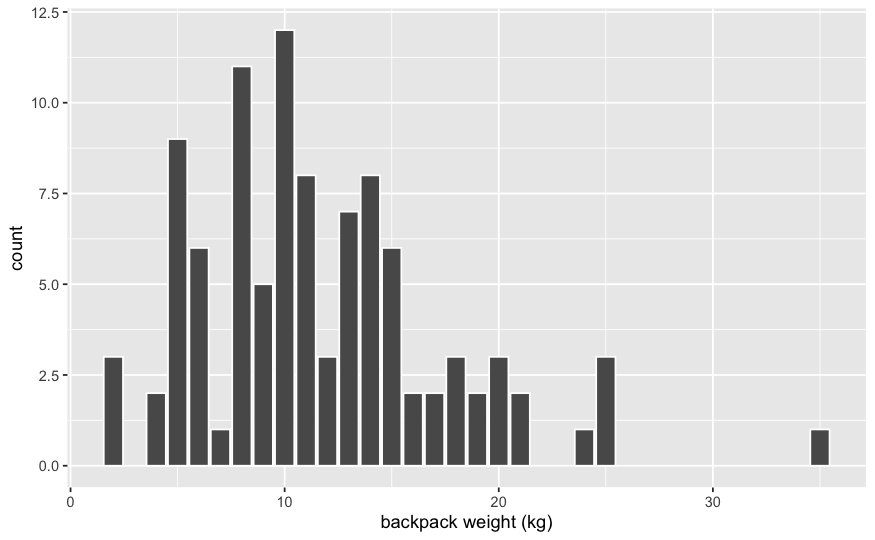

```r
ggplot(backpack) +
  geom_bar(aes(x = backpack_weight), col = "white") +
  xlab("backpack weight (kg)") +
  scale_fill_brewer(palette = 7)
```

#### Question 3

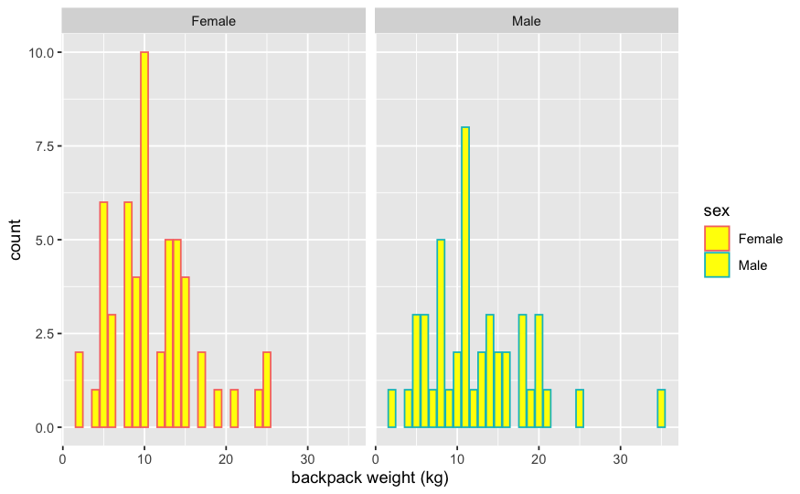

```r
ggplot(backpack) +
  geom_bar(aes(x = backpack_weight, colour = sex), fill = "yellow") +
  xlab("backpack weight (kg)") +
  facet_wrap(~sex, ncol = 2)
```

This graph compares the differences in backpack weight between female and male students. There are small differences between female and male weights; the variance of the male weight appears to be greater than the backpacks used by female students. There is a clear majority between 0 and 15kg in the female users whereas there is a consistent user-base of males using backpacks ranging from 5 to 20kg.

Sidenote: There are likely better ways of highlighting these differences.

#### Question 4

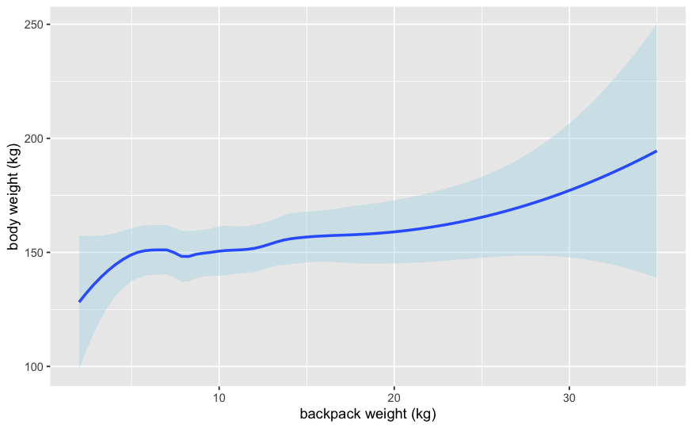

```r
ggplot(backpack) +
  aes(x = backpack_weight, y = body_weight) +
  geom_smooth(fill = "light blue") +
  xlab("backpack weight (kg)") +
  ylab("body weight (kg)")
```

This graph attempts to demonstrate an overall relationship between a student’s body weight and the weight of their respective backpacks. What we can observe is that there is a slow increase in body weight the heavier the back, with stress on low and high backpack weights having a more direct relationship on user body weight. Generally students with s body weight between ~145kg - 170kg will carry a backpack between 5kg - 20kg, however as we saw previously and shall check in the following graph, there is a disparity between gender in the data that may be skewing these results.

#### Question 5

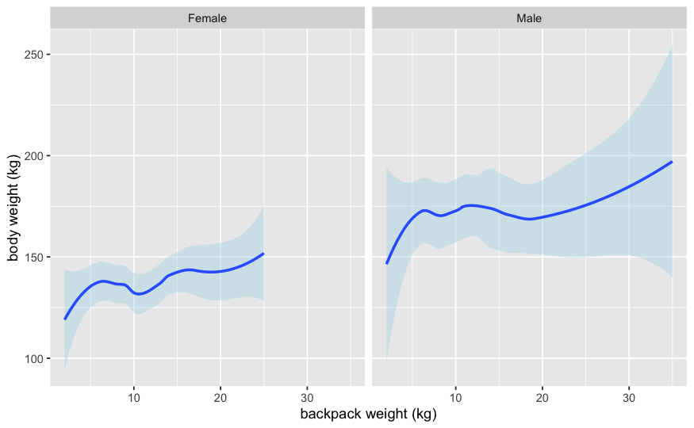

```r
ggplot(backpack) +
  aes(x = backpack_weight, y = body_weight) +
  geom_smooth(fill = "light blue") +
  xlab("backpack weight (kg)") +
  ylab("body weight (kg)") +
  facet_wrap(~sex, ncol = 2)
```

```r
NA
NA
```

#### Question 6

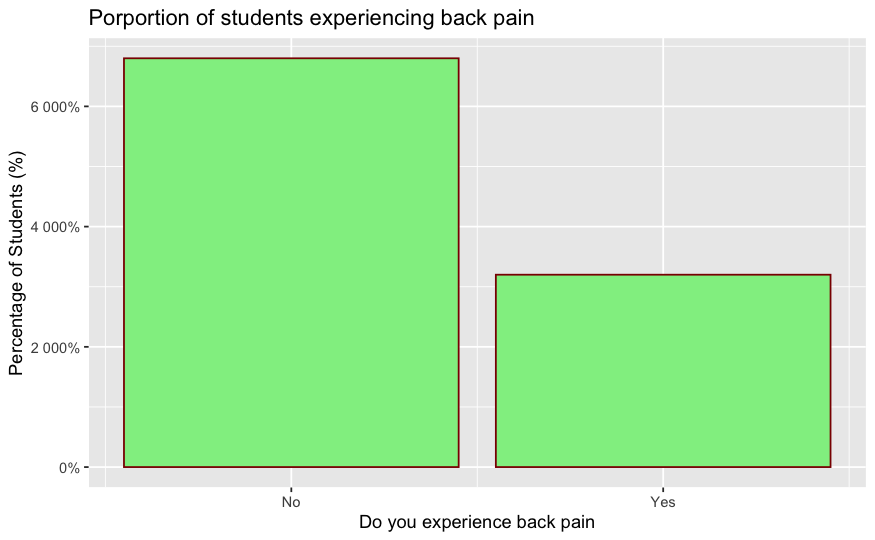

```r
ggplot(backpack) +
  geom_bar(aes(x = back_problems), col = "dark red", fill = "light green") +
  scale_x_continuous(breaks = c(0, 1),
                     labels = c("0" = "No",
                                "1" = "Yes")
                     ) +
  scale_y_continuous(labels = scales::percent) +
  labs(
    x = "Do you experience back pain",
    y = "Percentage of Students (%)",
    title = "Porportion of students experiencing back pain")
```

```r
NA
NA
NA
```

#### Question 7

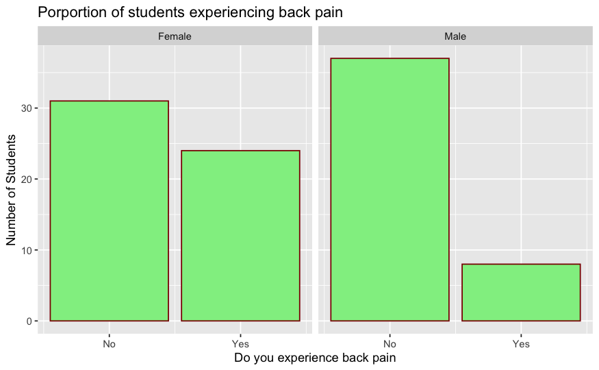

```r
ggplot(backpack) +
  geom_bar(aes(x = back_problems), col = "dark red", fill = "light green") +
  scale_x_continuous(breaks = c(0, 1),
                     labels = c("0" = "No",
                                "1" = "Yes")
                     ) +
  labs(
    x = "Do you experience back pain",
    y = "Number of Students", #Percentage of Students (%)
    title = "Porportion of students experiencing back pain") +
  facet_wrap(~sex)
```

```r
NA
NA
NA
NA
```

#### Question 8

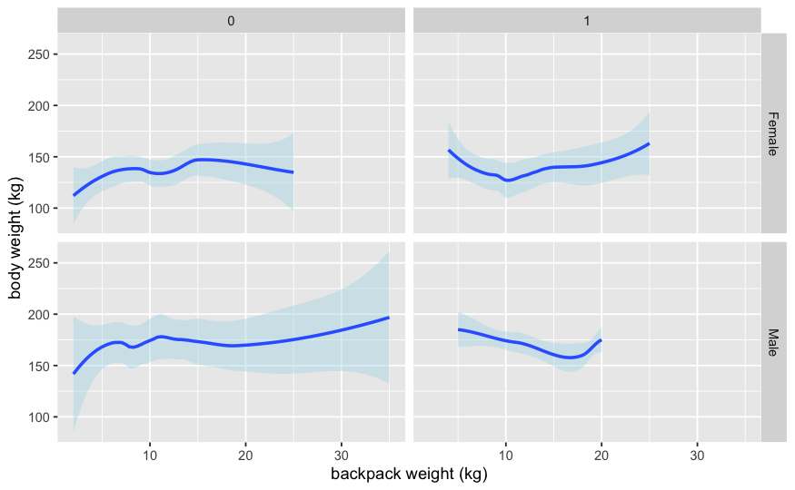

```r
ggplot(backpack) +
  aes(x = backpack_weight, y = body_weight) +
  geom_smooth(fill = "light blue") +
  xlab("backpack weight (kg)") +
  ylab("body weight (kg)") +
  facet_grid(sex~back_problems)
```

```r
NA
NA
```